# rozkład normalny

## Centralne Twierdzenie Graniczne

Mając daną wystarczająca dużą próbę z populacji ze skonczonym poziomem wariancji, rozkład danej zmiennej w tej probie upodabnia sie do rozkładu normalnego, a srednia z próby zmierza do średniej z całej populacji. Przy czym im wieksza próba tym odzwzorowanie lepsze.

## A w praktyce?

- nie musimy badać całej populacji, aby wiedzieć jak dana cecha się rozkłada w zbiorowości
- średnie wartości danej cechy są najliczniej reprezentowane
- im dalej oddalamy się od średniej, tym przypadków mniej

[figure not shown]

## Rozkład normalny

### najczęściej spotykany w przyrodzie rozkład zmiennych, np.:

- testy szkolne,
- testy inteligencji,
- wzrost i waga populacji,
- wynagrodzenia, wielkość produkcji, itp.

## Oznaczanie rozkladu normalnego

\[ X \sim N(\mu, \sigma^2) ~~\mu - srednia, ~~ \sigma^2- wariancja \]

lub

\[ X \sim N(\mu, \sigma) \]

**Im mniejsze odchylenie standardowe, tym rozklad jest bardziej skoncentrowany wokol sredniej oczekiwanej**

## Rozkład normalny w R

### d…()

### p…()

### r…()

### q…()

## Rozkład normalny w R

### dnorm()

### pnorm()

### rnorm()

### qnorm()

## Ćwiczenie 1

Na jednym wykresie narysuj funkcję gestosci prawdopodobienstwa dla N(2,8); N(0,1); N(-3,2)

## Ćwiczenie 1

Na jednym wykresie narysuj funkcję gestosci prawdopodobienstwa dla N(2,8); N(0,1); N(-3,2)

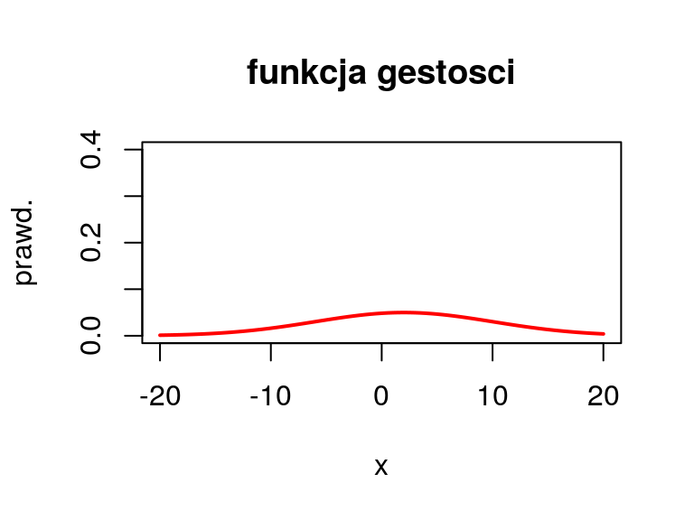

```r
# N(2,8)
# tworzymy sekwencje danych
x <- seq(-20, 20, by = 0.5)
# rysujemy rozkład normalny dla x
plot(x, dnorm(x,2,8), type="l", col="red", lwd=2,
     ylim=c(0,0.4), main="funkcja gestosci",
     ylab="prawd.", xlab="x")
```

## Ćwiczenie 1

Dodajemy linię dla rozkładu N(0,1)

```r
# N(0,1)
lines(x, dnorm(x,0,1), type="l", col="green", lwd=2)
```

## Ćwiczenie 1

Dodajemy linię dla rozkładu N(-3,2)

```r
# N(-3,2)
lines(x, dnorm(x,-3,2), type="l", col="blue", lwd=2)
```

## Ćwiczenie 1

i jeszcze legenda

```r
legend(45, 0.4, c("N~(2,8)","N~(0,1)", "N~(-3,2)"),
       lty=c(1,1), lwd=2, col=c("red", "green","blue"))
```

## Ćwiczenie 1 - efekt końcowy

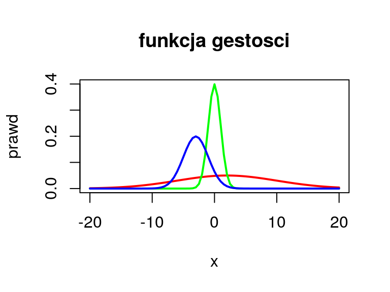

```r
plot(x, dnorm(x,2,8), type="l", col="red", lwd=2,
     ylim=c(0,0.4), main="funkcja gestosci",
     ylab="prawd", xlab="x")
lines(x, dnorm(x,0,1), type="l", col="green", lwd=2)
lines(x, dnorm(x,-3,2), type="l", col="blue", lwd=2)
legend(45,0.4, c("N~(2,8)","N~(0,1)", "N~(-3,2)"),
       lty=c(1,1), lwd=2, col=c("red", "green","blue"))
```

## Normal distribution

[figure not shown]

## Zadanie

### Narysuj dystrybuante dla powyższych 3 rozkładow normalnych (na jednym wykresie).

## Zadanie

### Narysuj dystrybuante dla powyższych 3 rozkładow normalnych (na jednym wykresie).

[figure not shown]

## Zadanie

### Narysuj dystrybuante dla powyższych 3 rozkładow normalnych (na jednym wykresie).

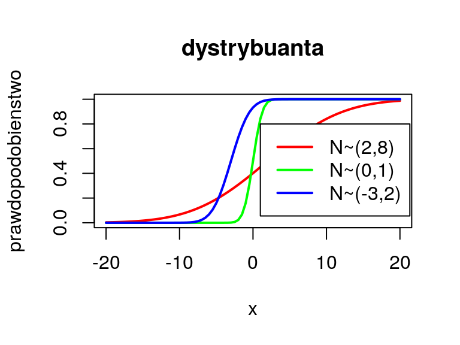

```r
plot(x, pnorm(x,2,8), type="l", col="red", lwd=2, ylim=c(0,1), main="dystrybuanta",
     ylab="prawdopodobienstwo", xlab="x")
lines(x, pnorm(x,0,1), type="l", col="green", lwd=2)
lines(x, pnorm(x,-3,2), type="l", col="blue", lwd=2)
legend(1,0.8, c("N~(2,8)","N~(0,1)", "N~(-3,2)"),
       lty=c(1,1), lwd=2, col=c("red", "green","blue"))
```

## Ćwiczenie:

Zidentyfikuj obszar zawierajacy 95% prawdopodpobienstwa rozkladu zmiennej dla powyzszych 3 rozkladow normalnych *(funkcja qnorm - funkcja kwantylowa, odwrotna dystrybuanta)*

## Pierwszy:

### N~(0,1) rozklad standardowy normalny;

Obszar zawierający 95% prawdopodobieństwa

```r
qnorm(0.975)
```

```
## [1] 1.959964
```

```r
qnorm(0.025)
```

```
## [1] -1.959964
```

### Dlaczego 0.975 a nie 0.95??

## Dwa ogony rozkładu normalnego

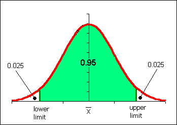

## Drugi:

```r
qnorm(0.975, 2,8)
```

```
## [1] 17.67971
```

```r
qnorm(0.025, 2,8)
```

```
## [1] -13.67971
```

## Trzeci

```r
qnorm(0.975, -3,2)
```

```
## [1] 0.919928
```

```r
qnorm(0.025, -3,2)
```

```
## [1] -6.919928
```